# PSYCH5080 Data Skills Assignment 2

School of Psychology and Neuroscience

# General Instructions

Welcome to your second Data Skills Assignment. This assignment has been designed to show you how your knowledge and skills have developed based on what we have covered in the [Fundamentals of Quantitative Analysis](https://psyteachr.github.io/quant-fun-v2) book. Remember to refer back to those skills and tasks because as we always say, only the data changes.

As you can see, along with this instructions HTML page, you have two data files (`.csv` files) and one .Rmd assignment file, currently called `GUID_PSYCH5080_DataSkills2.Rmd`. Again, it is the Rmd assignment file which you will edit and submit as your assignment. First you should set up a folder that you will use as your working directory; put the data files and the .Rmd file in that folder. Next you should open RStudio and set your working directory to your folder containing the .Rmd file and the two .csv data files. Note that if you are using the RServer you will need to upload the .Rmd file and the two data files to the RServer and will need to download the .Rmd from the RServer when you are finished.

Once you have set your working directory, you should open the .Rmd file within RStudio and save the .Rmd file, replacing the `GUID` part of the Rmd filename with your actual `GUID`, e.g. `9804672m_PSYCH5080_DataSkills2.Rmd`. The .Rmd file itself will currently knit as there are no errors in the code and this is a good test that you can perform from time to time, and before you submit, to make sure that there are still no errors in your code. Obviously this doesn’t mean that all your answers are correct; it just means that the code is error free.

As you will see in the .Rmd file there are a number of code chunks already set up. Some of the code chunks will require entering code or numbers, some code chunks will require deleting code, and some will require editing code. Follow the instructions of each task and pay close attention to what is asked. Do only what is asked. Do not change the names of any variables, tibbles, or objects given to you. In addition, as you will see, all the code chunks have names; the `TR901` to `TR911` next to the `r` inside the `{}` at the start of the code chunk. Do not change any of the code chunk names, or rules, that may appear within the `{}` as this may result in you receiving no grade for that question or for the entire assignment.

As we said, all tasks are achievable using the skills you have covered in the course so do remember to look back to see what you previously did. Your overall goal is to edit the code chunks to create a working code that does what each task asks for. Some examples of editing code chunks are shown here but they are not meant to cover every task, just to highlight some basics to help you. For example, you might go be asked to go from changing a NULL to enter a number

```r
number <- NULL
```

to

```r
number <- 1
```

or, for data wrangling, from:

```r
mydata <- NULL
```

to

```r
mydata <- group_by(data, variable) %>% summarise(mean_score = mean(score))
```

or, from a partial completed code:

```r
ggplot(NULL, aes(NULL, NULL)) + NULL
```

or, no code,

```r
##an empty code chunk
```

to

```r
ggplot(my_data, aes(x_axis, y_axis)) + geom_something()
```

or

```r
libary(broom)
```

or from

```r
answer_test <- 1
answer_test <- 2
```

to, deleting a line to leave only the correct answer,

```r
answer_test <- 2
```

In total, there are 11 tasks to complete in this assignment. Should you require any assistance or help, keep in mind the practical skills sessions, student/office hours, the book with all the tasks that you have thus far done, and the TEAMS channel.

## Background

The backdrop for the assignment is the following two studies:

1. Dijksterhuis, A. & van Knippenberg, A. (1998). *The relation between perception and behavior, or how to win a game of trivial pursuit. Journal of Personality and Social Psychology, 74(4), 865-877.* [Available through the University of Glasgow Library online resources](https://www.gla.ac.uk/myglasgow/library/)
2. O’Donnell, M., Nelson, L., et al., (preprint - 2017) *Multilab direct replication of: A variant of study 4 from Dijksterhuis, A. & van Knippenberg, A. (1998). The relation between perception and behavior, or how to win a game of trivial pursuit. Journal of Personality and Social Psychology, 74(4), 865-877.* [Available in PDF format by clicking here](https://www.psychologicalscience.org/redesign/wp-content/uploads/2017/11/RRR_ProfPrime_Ms_171013_ACPT.pdf)

The abstract of Dijksterhuis and van Knippenberg (1998) reads:

**The authors tested and confirmed the hypothesis that priming a stereotype or trait leads to complex overt behavior in line with this activated stereotype or trait. Specifically, 4 experiments established that priming the stereotype of professors or the trait intelligent enhanced participants’ performance on a scale measuring general knowledge. Also, priming the stereotype of soccer hooligans or the trait stupid reduced participants’ performance on a general knowledge scale. Results of the experiments revealed (a) that prolonged priming leads to more pronounced behavioral effects and (b) that there is no sign of decay of the effects for at least 15 min. The authors explain their results by claiming that perception has a direct and pervasive impact on overt behavior (cf. J. A. Bargh, M. Chen, & L. Burrows, 1996). Implications for human social behavior are discussed.**

The abstract of O’Donnell et al., (preprint - 2017) is as follows:

**Dijksterhuis and van Knippenberg (1998) reported that participants primed with an intelligent category (professor) subsequently performed 13.1% better on a trivia test than participants primed with an unintelligent category (soccer hooligans). Two unpublished replications of this study by the original authors, designed to verify the appropriate testing procedures, observed a smaller difference between conditions (2-3%) as well as a gender difference: men showed the effect (9.3% and 7.6%) but women did not (0.3% and -0.3%). The procedure used in those replications served as the basis for a multi-lab Registered Replication Report (RRR). A total of 40 laboratories collected data for this project, with 23 laboratories meeting all inclusion criteria. Here we report the meta-analytic result of those 23 direct replications (total N = 4,493) of the updated version of the original study, examining the difference between priming with professor and hooligan on a 30-item general knowledge trivia task (a supplementary analysis reports results with all 40 labs, N = 6,454). We observed no overall difference in trivia performance between participants primed with professor and those primed with hooligan (0.14%) and no moderation by gender.**

So as you can see the original and well-known *Professor Effect* or *Professor Priming*, which proposed that priming people as Professors made them perform better on a quiz than those primed as Hooligans, appears to not stand up to replication based on the results of this new **Multi-Lab RRR**. Fortunately for us, in order to build on our analytical and interpretation skills, the authors of the RRR have made all their data available on the [Open Science Framework](https://osf.io/k27hm/files/) which you can look at later if you like. But for now, the necessary data is made available to you on Moodle.

For this lab, we will focus on the data from two randomly selected labs: Angela Birt’s Lab (Canada) and David R. Shanks’ Lab (UK) - you can see the procedure for each lab on Pg 26 and Pg 35 of the RRR respectively to see how closely they followed the original procedures if you like, but again this is not necessary for today’s tasks.

First we will run some data-wrangling and visualisations to check assumptions. We will then look at the descriptives before attempting to replicate the findings of the RRR. Finally, we will end with an interpretation MCQ to check our understanding.

## Final Checks:

Before we start the assignment, here are some aspects to check:

1. The `Birt_data_complete.csv` file and the `Shanks_data_complete.csv` file are saved into a folder on your computer and you have manually set this folder as your working directory. **Do not set your working directory using code in the script**. Instead, manually set it using the `Session >> Set Working Directory` option from the top menu bar of RStudio. Also, **do not** at any time rename the .csv data files. They should be named exactly as above for the duration of this assignment. This is to ensure that your code will be reproducible when we assess it. We will only assess it against the above specifically named .csv files. **Remember**, `my_data.csv` and `my_data (1).csv` are two different data files and you should only use the names given to you.
2. The `.Rmd` file is saved in the same folder as the data files. For this assignment we ask that you save the .Rmd file with the format `GUID_PSYCH5080_DataSkills2.Rmd` where `GUID` is replaced with your `GUID`. For example, if your `GUID` was `9804672m` then you would rename the .Rmd as `9804672m_PSYCH5080_DataSkills2.Rmd`
3. Remember that if at any point you want to explore your data to become familiar with the variable names, noting any capital letters and punctuation, you can use `View()` or `glimpse()`. Use these functions only in the console window and not in the assignment .Rmd file. Never use `install.packages()` within this .Rmd file. Again if you need to use that function, run it only in your console window.
4. All rules regarding the submission of files for assessment are detailed on the Moodle Submission Page and on the AIS form on Moodle. Everyone is encouraged to make sure they are aware of these rules and have read them.

# Start of the Assignment

There now follows the instructions for the 11 tasks. You should complete these tasks on your .Rmd file in the correct and appropriate code chunks as stated in the tasks.

### Task 1: Load the Libraries

As always, analysis starts with libraries. Today you will need `broom` and `tidyverse`.

- First, in the `TR901` code chunk, add code to load in all of the stated libraries. Remember to load the `tidyverse` last.
  - **hint:** library(something)
  - **hint:** you need two libraries here so two library functions.
  - **note:** do not use `install.packages()` in this assignment file at all! If you need to use that function it should be used only in your console window and not in this assignment file.

```r
#empty
```

### Task 2: The Data

Now we have the appropriate packages and functions loaded, the next step is to load our data in so that we can work with it. In this assignment we have two datafiles that we need to load in and to store them as tibbles in individual objects.

- In the `TR902` code chunk, replace the NULLs with code using `read_csv()` to load in the data files as stated here:
  - Store the data from the Canadian `Birt` lab as a tibble in the object `dat_can`.
  - Store the data from the UK `Shanks` lab as a tibble in the object `dat_uk`.
- **hint:** If I wanted to load a datafile called `my_data.csv` and store it as a tibble in the object `responses`, I would replace `responses <- NULL` with `responses <- read_csv("my_data.csv")`
- **note:** You must use `read_csv()`. No other function will be considered correct as they change the name of variables and how the data is stored.
- **note:** between the quotation marks should only be the data file name and not a directory or path specific to your computer. E.g. `my_data.csv` and not `C:/my_name/my_computer/my_folder/my_data.csv`

```r
dat_can <- NULL
dat_uk <- NULL
```

**View the data**

It is always a good idea to familiarise yourself with the layout of the data that you have just loaded in. You can do this through using `glimpse()` or `View()` in the console window, but you must never put these functions in your assignment file. We would recommend having a look at your data now before moving on to the rest of the tasks.

### Task 3: Wrangling 1

Having viewed the data we now want to do some wrangling to get the data into shape so that we can start analysing it. We will start with the Canadian data before working on the UK data.

Using the Canadaian data `dat_can` do the following two steps in **one pipeline** - i.e. `function() %>% function()`, replacing the NULL in the `TR903` code chunk, and storing the output as a tibble in the object `dat_can_rdc`.

1. First, from `dat_can` select, in this order, the columns `CODED`, `LANGUAGE`, `COUNTRY`, `CORRECT_PCT` so that you have only those four columns and that they are in the stated order.
2. Next, given that the priming experiment was in English and the questions were in English, `LANGUAGE` may have had an influence that is not controlled for. Using a pipe, filter the data from the first step to keep only those who have stated their main `LANGUAGE` is `ENGLISH`.
- **Hint:** select() %>% filter()
- **Check your work:** As a result of these steps `dat_can_rdc` should have 87 observations across 4 columns. The order of the columns is CODED, LANGUAGE, COUNTRY, CORRECT_PCT. The data comes from the Canadian lab. And that you have piped between the two functions.

```r
dat_can_rdc <- NULL
```

### Task 4 - Creating Factors

Now, as we have mentioned previously, it can be helpful to work with categorical data as factors instead of numerical 1s and 0s. As such we should convert the values in `CODED` from numerical to factors.

- In the `TR904` code chunk, use `mutate()` to convert the data in the column `CODED`, within `dat_can_rdc`, into a factor and store this new tibble in the object `dat_can_mut`. Do not change the name of `CODED` column. Keep the name of the column as `CODED`.
- **hint:** Activity 2 in the Intro to Data Visualisation would be an example.
- **check your work:** the data within `dat_can_mut` will look very similar to `dat_can_rdc` with the one exception that the data within the CODED column is stored as a Factor.

```r
dat_can_mut <- NULL
```

### Task 5 - The UK Dataset

And now we want to do the same for the UK data:

- Replace the NULL in the `TR905` code chunk to do the same steps from TASK 3 and 4 for the UK data set in **one pipeline** - i.e. `select() %>% mutate() %>% filter()` - and store the output as a tibble in the object called `dat_uk_mut`.
- **hint:** This will require two pipes, one from the select to the mutate and one from the mutate to the filter.
- **hint:** If you have done the previous steps correctly, the code for this task is very similar as in task 3 and 4 - it is really a case of getting the pipes to work and remembering to change the data.
- **note:** Do not create any new objects to complete this task. It must be one pipeline chain and stored in `dat_uk_mut`.

**Check your work:** As a result of these steps you should have a tibble with 60 observations across 4 columns. The order of the columns is CODED, LANGUAGE, COUNTRY, CORRECT_PCT. The data comes from the UK lab. The data within the CODED column is stored as a Factor. And that you have piped between functions.

```r
dat_uk_mut <- NULL
```

### Task 6: Combine the data

Now we want to combine the data from the UK and Canada together into one larger tibble. This is actually a lot easier than it looks because the two tibbles have the same column names and we can just place one on top of the other giving us a tibble with 4 columns and 147 observations (rows). The 147 observations is made up of 87 observations from Canada and 60 observations from the UK.

Below are four lines of code. One of them performs the action we want. Have a look at the four options.

```
inner_join(dat_can_mut, dat_uk_mut, "COUNTRY")
anti_join(dat_can_mut, dat_uk_mut, "COUNTRY")
bind_rows(dat_can_mut, dat_uk_mut)
bind_cols(dat_can_mut, dat_uk_mut)
```

- Copy and paste one of the code lines to replace the NULL in the `TR906` code chunk below so that the code combines `dat_can_mut` and `dat_uk_mut` and store the new tibble within the object `combined_data`.
- **hint:** do nothing other that replace the NULL with the one line of code that gives us the correct output. Do not change the code lines.
- **hint:** use the dimensions stated above to check your work.
- **check your work:** be sure that the new tibble is stored in the object `combined_data` - i.e. you have only replaced the NULL and not deleted the object name.

```r
combined_data <- NULL
```

### Task 7 - Selecting columns

We have a lot of columns at the moment in `combined_data` and we do not need them all so let’s select just the ones we want.

- Replace the NULL in the `TR907` code chunk with `select()` so that it keeps only `CODED`, `COUNTRY` and `CORRECT_PCT` from `combined_data` and stores them as a tibble in the object `combined_data_rdc`. You must select the columns so that they appear in the order stated in this task.
- **hint:** be sure to check the order of your columns in the new object.
- **hint:** remember that spelling and capitalisation is very important. `COUNTRY` is not the same as `Country`.

```r
combined_data_rdc <- NULL
```

### Task 8 - Visualisation

Before running any analysis you should always be in the habit of checking assumptions such as variance, normality, etc. One great way of doing this (as you know) is through generating informative plots.

- In the `TR908` code chunk, add code to closely replicate the figure shown to you. We have given you a selection of code lines to help here. You will not need to use them all as not all of them are correct. By choosing the correct four lines of code and putting them in the correct order you will create the figure shown. You will not need to edit the four correct lines as when placed in the correct order the will produce the shown figure. Finally, as you can see we have given no object to store the figure in as it should not be stored, so do not store the figure in an object - that means that when you knit the .Rmd file the figure should display in the HTML output.
- Note that this task is really about putting lines of a pipe in the correct order and there is no need to edit the individual lines.

```
ggplot(combined_data_rdc, aes(COUNTRY, CORRECT_PCT, fill = COUNTRY)) +
ggplot(combined_data_rdc, aes(CODED, CORRECT_PCT, fill = COUNTRY)) +
ggplot(combined_data_rdc, aes(CORRECT_PCT, CODED, fill = COUNTRY)) +

geom_viloin() + goem_boxplot() +
geom_vilion() + geom_boxpolt() +
geom_violin() + geom_boxplot() +

scale_x_discrete(name = "Condition", labels = c("Hooligan", "Professor")) +
scale_y_discrete(name = "Condition", labels = c("Hooligan", "Professor")) +
scale_x_continuous(name = "Condition", labels = c("Hooligan", "Professor")) +

facet_wrap(~CODED)
facet_wrap(~COUNTRY)
facet_wrap(~CORRECT_PCT)
```

```r
#empty
```

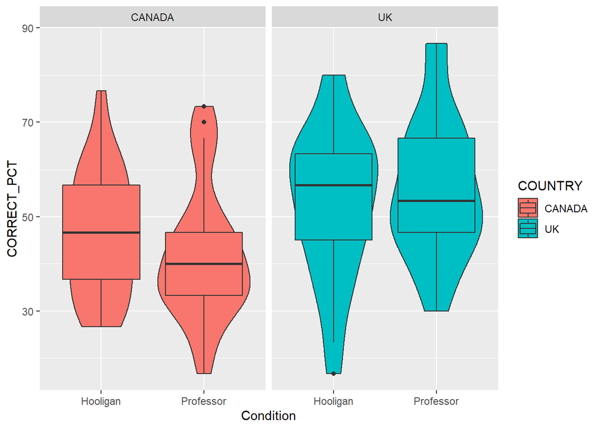

### Task 9: Descriptives

Looking good! Next, when writing up experiments we need to have a note of measures of spread (e.g. standard deviation) and central tendency (e.g. mean) for each condition, as well as how many people there are in each condition.

- Using **one pipeline** replace the `NULL` in the `TR909` code chunk below to recreate the descriptives table shown below. Pay particular attention to the names and order of columns, and order of rows.

Store the output as a tibble in the object called `descriptives`. Your `descriptives` should match the structure of the table shown, meaning that the order of columns and rows is the same, but with your actual values replacing the question marks. Do not round up any of the values. Leave them as they are.

Again we have some starter code here to help. Put the lines of code in the correct order in the TR909 code chunk and replace the NULLs to produce your table.

- **hint:** start with `combined_data_rdc`
- **hint:** the NULLs are a clue to how many grouping variables there will be in the group_by assuming one is the tibble/data.

```
group_by(NULL, NULL, NULL) %>%
summarise(N_CORRECT = NULL, MEAN_CORRECT = NULL, SD_CORRECT = NULL)
```

```r
descriptives <- NULL
```

| COUNTRY | CODED | N_CORRECT | MEAN_CORRECT | SD_CORRECT |
| --- | --- | --- | --- | --- |
| CANADA | 0 | ? | ? | ? |
| CANADA | 1 | ? | ? | ? |
| UK | 0 | ? | ? | ? |
| UK | 1 | ? | ? | ? |

### Task 10: t-test

So the data looks normally distributed, good! And it is continuous, fabulous! And we assume the data is also independent, excellent! So far so good. And we know from previous reading that we don’t really need to care about variance as we should be using the Welch’s between-subjects t-test anyway as it is better for the False Positive Rate, right? So let’s do that now!

- Replace the NULL in the `TR910` code chunk with one pipeline of code to run a Welch’s between-subjects t-test to compare **percentage correct** for those in the hooligan condition versus those in the professor condition from the **Canadian** lab group.
- Tidy the output into a tibble.
- Add a column that calculates the appropriate effect size for this analysis and store this tibble in the object called `ttest_can` so that it matches the structure of table shown below.

Again here is a selection of code lines to help you. You will not use all of these code lines but must select the correct lines, in the correct order, to create what is described above. Note that you do not needed to edit the code lines at all as when they are placed in the correct order they will produce the required output but with the actual values replacing the question marks. We haven’t really seen the `data = .` approach before but it is deliberate and it will work if the lines of code are in the correct order. It tells the code to “put the tibble name here” and you should not edit it. In short, this task is about putting lines in order and checking your output.

```
filter(combined_data_rdc, CODED == 0) %>%
filter(combined_data_rdc, COUNTRY == "CANADA") %>%
filter(combined_data_rdc, CODED == 1) %>%
filter(combined_data_rdc, COUNTRY == "UK") %>%

t.test(CODED ~ CORRECT_PCT, data = ., var.equal = FALSE, alternative = "two.sided") %>%
t.test(CORRECT_PCT ~ CODED, data = ., var.equal = FALSE, alternative = "two.sided") %>%
t.test(CORRECT_PCT ~ CODED, data = ., var.equal = TRUE, alternative = "two.sided") %>%
t.test(CODED ~ CORRECT_PCT, data = ., var.equal = TRUE, alternative = "two.sided") %>%

tidy() %>%
broom() %>%
merge() %>%
split() %>%

mutate(d = statistic/sqrt(ceiling(parameter) + 1))
mutate(d = (2^statistic)/sqrt(parameter))
mutate(d = statistic/sqrt(parameter + 1))
mutate(d = (2*statistic)/sqrt(parameter))
```

```r
ttest_can <- NULL
```

| estimate | estimate1 | estimate2 | statistic | p.value | parameter | conf.low | conf.high | method | alternative | d |
| --- | --- | --- | --- | --- | --- | --- | --- | --- | --- | --- |
| ? | ? | ? | ? | ? | ? | ? | ? | ? | ? | ? |

### Task 11: The Final Interpretation

Here is the output of the UK comparison as well:

| estimate | estimate1 | estimate2 | statistic | p.value | parameter | conf.low | conf.high | method | alternative | d |
| --- | --- | --- | --- | --- | --- | --- | --- | --- | --- | --- |
| -3.2211 | 52.83951 | 56.06061 | -0.8079652 | 0.4226606 | 53.92568 | -11.21417 | 4.771967 | Welch Two Sample t-test | two.sided | -0.2200518 |

Now, having gathered all the information, read through the below four statements. One of the sentences is a coherent summary consistent with having carried out the above analysis correctly comparing Professors and Hooligans in the UK and Canada.

1. A Welch’s between-subjects t-test showed that there was no significant difference in terms of priming between the Professor and Hooligan conditions in either the Canadian Birt Lab (t(80.72) = 1.58, p = .118, d = .35) nor the UK Shanks Lab (t(53.93) = 0.81, p = .423, d = .22). Thus the findings of the RRR by O’Donnell et al., (2017), for the labs of Birt and Shanks, are not consistent with the proposed Professor Priming Effect found by Dijksterhuis and van Knippenberg (1998).
2. A Welch’s between-subjects t-test showed that there was a significant difference in terms of priming between the Professor and Hooligan conditions in the Canadian Birt Lab (t(80.72) = 1.58, p = .118, d = .35) and the UK Shanks Lab (t(53.93) = 0.81, p = .423, d = .22). Thus the findings of the RRR by O’Donnell et al., (2017), for the labs of Birt and Shanks, are not consistent with the proposed Professor Priming Effect found by Dijksterhuis and van Knippenberg (1998).
3. A Welch’s between-subjects t-test showed that there was a significant difference in terms of priming between the Professor and Hooligan conditions in the Canadian Birt Lab (t(80.72) = 1.58, p = .118, d = .35) and the UK Shanks Lab (t(53.93) = 0.81, p = .423, d = .22). Thus the findings of the RRR by O’Donnell et al., (2017), for the labs of Birt and Shanks, are consistent with the proposed Professor Priming Effect found by Dijksterhuis and van Knippenberg (1998).
4. A Student’s between-subjects t-test showed that there was no significant difference in terms of priming between the Professor and Hooligan conditions in either the Canadian Birt Lab (t(80.72) = 1.58, p = .118, d = .35) nor the UK Shanks Lab (t(53.93) = 0.81, p = .423, d = .22). Thus the findings of the RRR by O’Donnell et al., (2017), for the labs of Birt and Shanks, are consistent with the proposed Professor Priming Effect found by Dijksterhuis and van Knippenberg (1998).

Taking into consideration the original idea of the Professor Priming Experiment and the analysis we have conducted today, only one of the statements above is a valid and correct interpretation of the outcome. Which one?

- In the `TR911` code chunk below there are five lines of code where four select one of the possible answers and one line selects an impossible answer. Of the possible answers, three are incorrect. In the `TR911` code chunk, delete all of the lines that select an incorrect answer and an impossible answer to leave just one line of code that states the correct answer. For example, if you thought that the first statement above gave the correct answer then you would delete all other code lines **except** the one that reads as `answer_TR911 <- 1`.
  - **hint:** only one answer is correct and if none of the answers appear correct based on your output of Task 10 then it is likely you have not completed the previous tasks correctly.
  - **check:** when you are finished this Task, the `TR911` code chunk should have only one line of code in it.

```r
answer_TR911 <- 1
answer_TR911 <- 2
answer_TR911 <- 3
answer_TR911 <- 4
answer_TR911 <- 999
```

# Finished

Well done, you are finished. Now it would be an excellent idea to save your code, close RStudio and R, reopen RStudio and R, reopen your code, and then knit your code one last time to HTML. If there are no errors in your coding then your code should produce an HTML output with all your answers in place. If any errors appear you should try and rectify them before submitting the .Rmd file. Remember this does not mean that your answers are correct, it just means that you have code that runs. Remember to submit your assignment through Moodle in the format of `GUID_PSYCH5080_DataSkills2.Rmd` by the deadline, however do read below as some final checks.

**Make sure that before you submit that :**

1. All the code chunks are named as they were in the original file, TR901 to TR911. All code chunks start and end correctly with backticks.
2. That all variables, tibbles, objects, columns, etc are named as they were originally given or asked to be named. Check spelling, e.g. `answers` is not the same as `anwser` nor `answer` and only one will be considered correct regardless of what was meant. Be reproducible!
3. That when you knit the file as an HTML, a webpage is produced and that the code does not crash due to an error.
4. That you are submitting the file as an .Rmd file and nothing else.
5. That the file you want to submit is the file you are about to submit as we can not return files for a second chance of submission.